# Milestone Report

Diana Giraldo

October 15, 2020

## Summary

This report contains:

- An exploratory analysis of the text data
- A brief exploration of the data model that will be used to create the prediction algorithm.

## Exploring data

The main goal of this section is to show how to read the data and have some insight about the content.

### Reading text data

The first step is to have a global description of the 3 sources of text data: news, blogs and twitter. To do so, I counted the lines of each file and read each one of them once to calculate the average number of words per line:

```r
TS <- data.frame(source = c("news", "blogs", "twitter"),
                 nlines = NA, av.words = NA)

for (s in 1:3){
    infile <- sprintf("data/en_US/en_US.%s.txt", TS$source[s])
    TS$nlines[s] <- countLines(infile)
    con <- file(infile)
    tmp <- readLines(con)
    close(con)
    TS$av.words[s] <- round(mean(sapply(strsplit(tmp, "\\s+"), length), na.rm = TRUE), digits = 2)
    rm(tmp)
}

kable(TS, col.names = c("Text source", "lines of text", "average words per line"))
```

| Text source | lines of text | average words per line |
| --- | --- | --- |
| news | 1010242 | 34.02 |
| blogs | 899288 | 41.52 |
| twitter | 2360148 | 12.87 |

For the next exploratory steps we can can only read a fraction `fr` of the lines in each file and put them in a single predefined data.frame structure `D`:

```r
fr <- 0.05
TS <- mutate(TS, lines2read = round(nlines*fr))
D <- data.frame(txt = character(sum(TS$lines2read)), stringsAsFactors = FALSE)

for (s in 1:3){
    infile <- sprintf("data/en_US/en_US.%s.txt", TS$source[s])
    con <- file(infile)
    tmp <- readLines(con, n = TS$lines2read[s])
    close(con)
    if (s == 1){
        tmp_idx <- seq(1, TS$lines2read[s])
    } else{
        tmp_idx <- seq((TS$lines2read[s-1] + 1), (TS$lines2read[s-1] + TS$lines2read[s]))
    }
    D[tmp_idx, 1] <- tmp
    rm(tmp, tmp_idx)
}
```

The first 3 lines in `D` are:

| txt |
| --- |
| He wasn’t home alone, apparently. |
| The St. Louis plant had to close. It would die of old age. Workers had been making cars there since the onset of mass automotive production in the 1920s. |
| WSU’s plans quickly became a hot topic on local online sites. Though most people applauded plans for the new biomedical center, many deplored the potential loss of the building. |

## Data Model

The relationships between words can be modelled as N-grams, in this case, single words are considered 1-grams. We can create general functions to count and plot the histograms for the most common N-grams in text data:

```r
freq_ngram <- function(A, ng){
    freq <- A %>%
    unnest_tokens(output = n.gram, input = txt, token = "ngrams", n = ng) %>%
    count(n.gram, sort = TRUE)
    return(freq)
}

hist_ngram <- function(freq, ntop, ng){
    pl <- ggplot(freq[1:ntop,], aes(x = n.gram, y = n)) + geom_bar(stat = "identity") +
        labs(title  = sprintf("Frequency of the top %d %d-grams", ntop, ng)) + theme_minimal() +
        theme(axis.text.x = element_text(angle = 90, vjust = 0.5, hjust=1))
    return(pl)
}
```

### Frequency of words

Then we can use this function to plot the histogram of the 15 most frequent words by specifying the parameters:

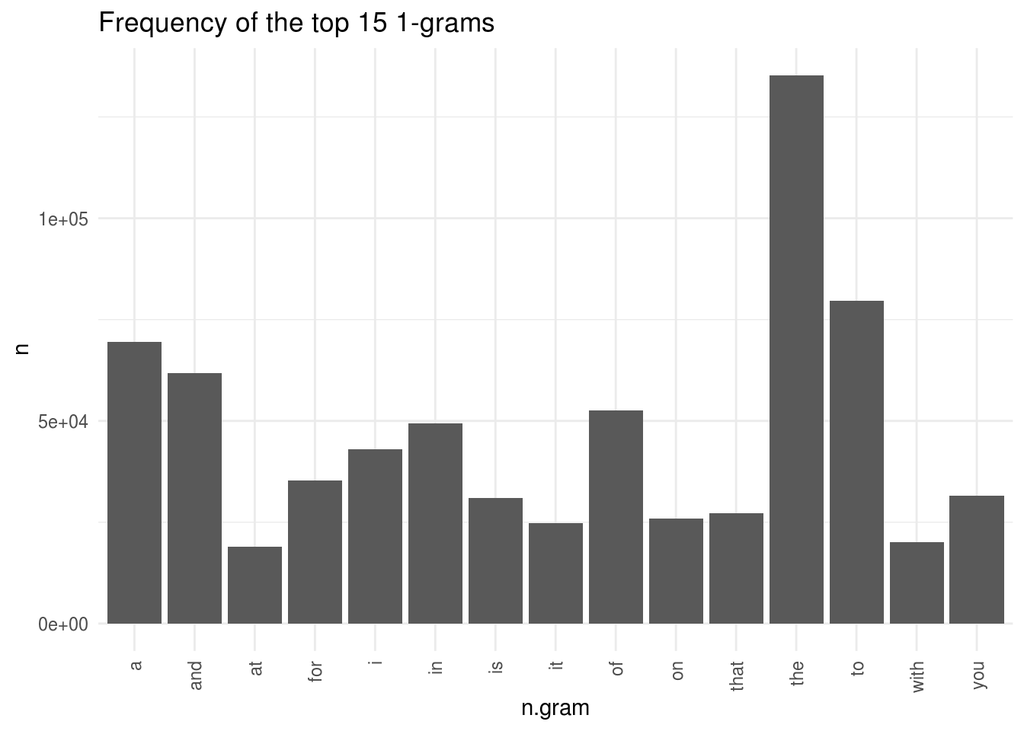

As expected, the most frequent word in english text is “the” followed by “to” and “a”.

### Frequency of 2-grams and 3-grams

Using the same functions, we can plot the 10 most common 2-grams:

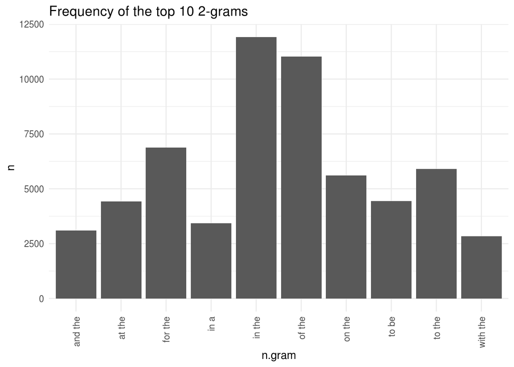

And the 20 most common 3-grams:

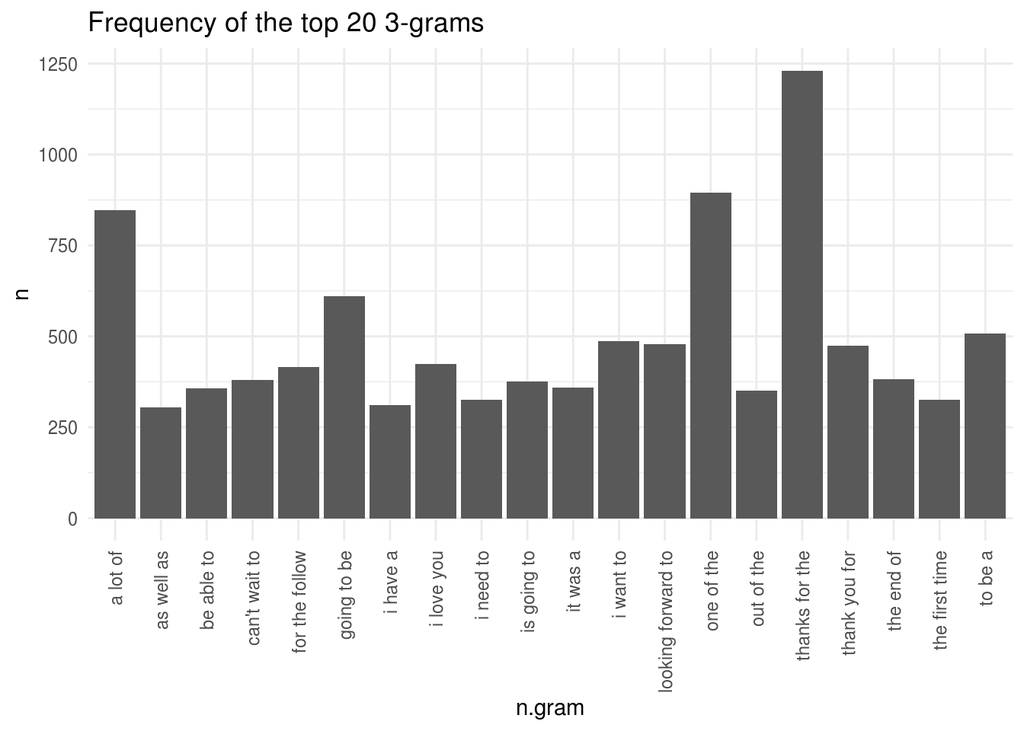